# Project: Investigate a Dataset (Replace this with something more specific!)

### Q2. The Nature of relationship between Budget vs Profit, Budget vs Ratings & Rating vs Profit

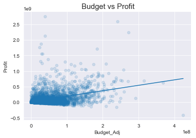

```python
# scatter plot budget vs profit
plt.scatter(df_bud_rev_nzero['budget_adj'], df_bud_rev_nzero['profit'], s=30, alpha=0.15, marker='o')
plt.plot(np.unique(df_bud_rev_nzero['budget_adj']), np.poly1d(np.polyfit(df_bud_rev_nzero['budget_adj'],df_bud_rev_nzero['profit'], 1))(np.unique(df_bud_rev_nzero['budget_adj'])))
#x-axis label name
plt.xlabel('Budget_Adj', fontsize = 10)
#y-axis label name
plt.ylabel('Profit', fontsize=10)
plt.title(' Budget vs Profit', fontsize=15);
```

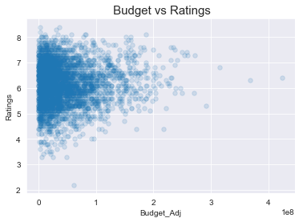

```python
# scatter plot budget vs ratings
plt.scatter(df_bud_rev_nzero['budget_adj'], df_bud_rev_nzero['vote_average'], s=30, alpha=0.15, marker='o')
#x-axis label name
plt.xlabel('Budget_Adj', fontsize = 10)
#y-axis label name
plt.ylabel('Ratings', fontsize=10)
plt.title(' Budget vs Ratings', fontsize=15);
```

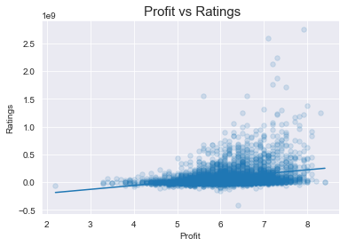

```python
# scatter plot profit vs ratings
plt.scatter(df_bud_rev_nzero['vote_average'], df_bud_rev_nzero['profit'], s=30, alpha=0.15, marker='o')
plt.plot(np.unique(df_bud_rev_nzero['vote_average']), np.poly1d(np.polyfit(df_bud_rev_nzero['vote_average'],
                                                                           df_bud_rev_nzero['profit'], 1))
                                                                           (np.unique(df_bud_rev_nzero['vote_average'])))
#x-axis label name
plt.xlabel('Profit', fontsize = 10)
#y-axis label name
plt.ylabel('Ratings', fontsize=10)
plt.title(' Profit vs Ratings', fontsize=15);
```

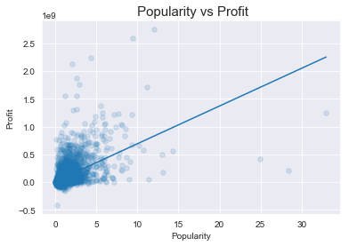

```python
# scatter plot popularity vs profit
plt.scatter(df_bud_rev_nzero['popularity'], df_bud_rev_nzero['profit'], s=30, alpha=0.15, marker='o')
plt.plot(np.unique(df_bud_rev_nzero['popularity']), np.poly1d(np.polyfit(df_bud_rev_nzero['popularity'],
                                                                           df_bud_rev_nzero['profit'], 1))
                                                                           (np.unique(df_bud_rev_nzero['popularity'])))
#x-axis label name
plt.xlabel('Popularity', fontsize = 10)
#y-axis label name
plt.ylabel('Profit', fontsize=10)
plt.title(' Popularity vs Profit', fontsize=15);
```

From The above 4 Scatter Plots, we Can conclude

1. Budget vs Profit: Weak +ve Correlation, in most of the cases, budget is not driving profits linearly
2. Budget vs Ratings: Ratings of the movie does not depend on budget
3. Profit vs Ratings: Here also we are seeing a weak +ve correlation. A movie with good ratings might not always be commercially successful.
4. Popularity vs Profit: Here we can see a moderate +ve correlation. Popularity of a movie might drive the profit linearly.

### Q3. The movie with maximum profit and maximum loss from the data

```python
#max_profit
max_profit=df_bud_rev_nzero.query('profit==profit.max()')
max_profit
```

|  | id | imdb_id | popularity | budget | revenue | original_title | cast | homepage | director | tagline | ... | runtime | genres | production_companies | release_date | vote_count | vote_average | release_year | budget_adj | revenue_adj | profit |
| --- | --- | --- | --- | --- | --- | --- | --- | --- | --- | --- | --- | --- | --- | --- | --- | --- | --- | --- | --- | --- | --- |
| 1329 | 11 | tt0076759 | 12.037933 | 11000000 | 775398007 | Star Wars | Mark Hamill\|Harrison Ford\|Carrie Fisher\|Peter ... | http://www.starwars.com/films/star-wars-episod... | George Lucas | A long time ago in a galaxy far, far away... | ... | 121 | Adventure\|Action\|Science Fiction | Lucasfilm\|Twentieth Century Fox Film Corporation | 3/20/77 | 4428 | 7.9 | 1977 | 3.957559e+07 | 2.789712e+09 | 2.750137e+09 |

1 rows × 22 columns

```python
#max_loss
max_loss=df_bud_rev_nzero.query('profit==profit.min()')
max_loss
# print('The movie which went through the biggest loss is {} with the rating {}'.format(max_loss['original_title'],max_loss['vote_average']))
```

|  | id | imdb_id | popularity | budget | revenue | original_title | cast | homepage | director | tagline | ... | runtime | genres | production_companies | release_date | vote_count | vote_average | release_year | budget_adj | revenue_adj | profit |
| --- | --- | --- | --- | --- | --- | --- | --- | --- | --- | --- | --- | --- | --- | --- | --- | --- | --- | --- | --- | --- | --- |
| 2244 | 46528 | tt1032751 | 0.25054 | 425000000 | 11087569 | The Warrior's Way | Kate Bosworth\|Jang Dong-gun\|Geoffrey Rush\|Dann... | http://www.iamrogue.com/thewarriorsway | Sngmoo Lee | Assassin. Hero. Legend. | ... | 100 | Adventure\|Fantasy\|Action\|Western\|Thriller | Boram Entertainment Inc. | 12/2/10 | 74 | 6.4 | 2010 | 425000000.0 | 11087569.0 | -413912431.0 |

1 rows × 22 columns

```python
#Number of Movies with Profit
df_bud_rev_nzero.query('profit>0')['id'].count()
```

```
2778
```

```python
#Number of Movies with Loss
df_bud_rev_nzero.query('profit<=0')['id'].count()
```

```
1076
```

The number of movies with profit is 2,778 and number of movies with loss is 1,076

### Q4. Check the ratings of the top 10 commercially most successful movies

```python
#Average Rating of Commercially Success Movies
df_direc_hit=df_bud_rev_nzero.query('profit>=profit.nlargest(10).min()')
df_direc_hit['vote_average'].mean()
```

```
7.17
```

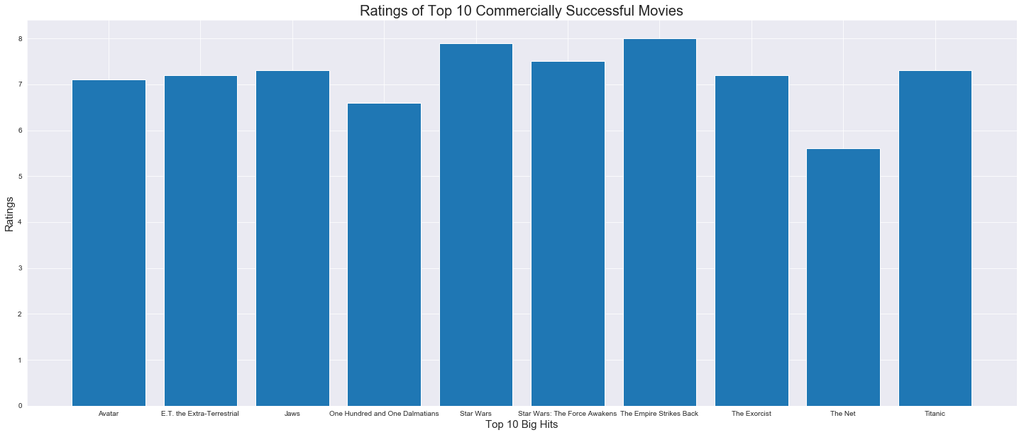

```python
#Top 10 Commercially Success Movies and their Ratings
direc_vot_avg=df_direc_hit.groupby('original_title').mean()['vote_average']
sns.set_style('darkgrid')
plt.subplots(figsize=(25,10))
plt.bar(direc_vot_avg.index,direc_vot_avg)
plt.title('Ratings of Top 10 Commercially Successful Movies', fontsize = 20)
plt.xlabel('Top 10 Big Hits', fontsize = 15)
plt.ylabel('Ratings', fontsize = 15);
```

In the top 10 commercially most successful movies, the average rating is 7.2. The hightest rating is 8 of 'The Empire Strikes Back' and the lowest is 5.6 of 'The Net'

### Q5. Count of movies with +ve profits over the years and the average profits by years

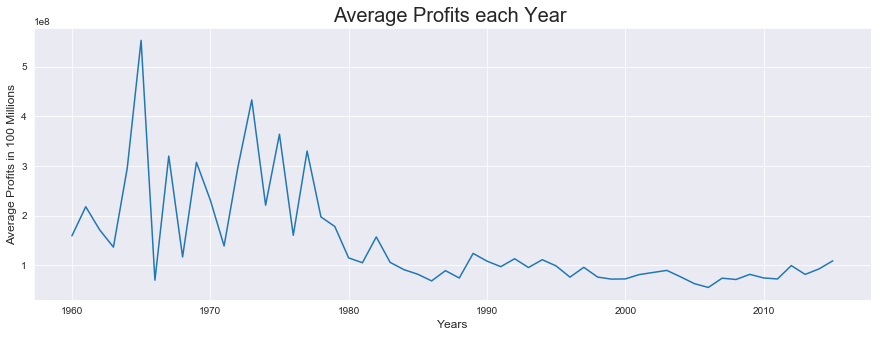

```python
#Average profit in years
df_profit_mean=df_bud_rev_nzero.groupby('release_year')['profit'].mean()
df_profit_mean

#Give the size of the figure
plt.figure(figsize=(15,5))

#plot the diagram
plt.plot(df_profit_mean);

#x-axis label name
plt.xlabel('Years', fontsize = 12)
#y-axis label name
plt.ylabel('Average Profits in 100 Millions', fontsize=12)
#title of the graph
plt.title('Average Profits each Year ', fontsize=20);
```

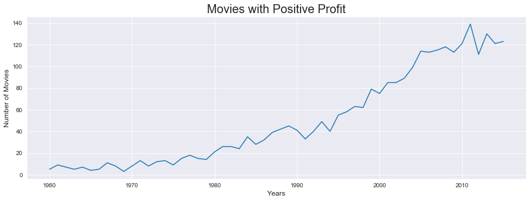

```python
#Count of profitable movies in years
df_profit_count=df_bud_rev_nzero.query('profit>0').groupby('release_year')['profit'].count()
df_profit_count

#Give the size of the figure
plt.figure(figsize=(15,5))

#plot the diagram
plt.plot(df_profit_count);

#x-axis label name
plt.xlabel('Years', fontsize = 12)
#y-axis label name
plt.ylabel('Number of Movies', fontsize=12)
#title of the graph
plt.title('Movies with Positive Profit', fontsize=20);
```

## Conclusions

```python
from subprocess import call
call(['python', '-m', 'nbconvert', 'Investigate_a_Dataset.ipynb'])
```

```
4294967295
```